# Sentiment Analysis in R

Luc Gendrot

March 9, 2016

## Sentiment Analysis in R in 4 Easy Functions

First we must load the required packages

```r
library("rmongodb")
library("dplyr")
library("randomForest")
library("dplyr")
library("plyr")
library("class")
library("e1071")
library("nnet")
library("neuralnet")
library("randomForest")
library("ranger")
```

In order to score text for sentiment, a number of pre-processing steps need to occur in order to make the text interpretable for predictive models.

### 1. Tokenization

The first step is Tokenization: the process of removing uninformative “stop” words such as “and”, “the”, “of”, “or” etc. As well as splitting the document into individual words. Since we’re doing sentiment analysis on tweets, we’ll also remove #hashtags and @signs.

```r
tokenize <- function(documents){
  # Lowercase all words for convenience
  doc <- tolower(documents)

  # Remove all #hashtags and @mentions
  doc <- gsub("(?:#|@)[a-zA-Z0-9_]+ ?", "", doc)

  # Remove words with more than 3 numbers in them (they overwhelm the corpus, and are uninformative)
  doc <- gsub("[a-zA-Z]*([0-9]{3,})[a-zA-Z0-9]* ?", "", doc)

  # Remove all punctuation
  doc <- gsub("[[:punct:]]", "", doc)

  # Remove all newline characters
  doc <- gsub("[\r\n]", "", doc)

  # Regex pattern for removing stop words
  stop_pattern <- paste0("\\b(", paste0(stopwords("en"), collapse="|"), ")\\b")
  doc <- gsub(stop_pattern, "", doc)

  # Replace whitespace longer than 1 space with a single space
  doc <- gsub(" {2,}", " ", doc)

  # Split on spaces and return list of character vectors
  doc_words <- strsplit(doc, " ")
  return(doc_words)
}
```

### 2. Building the Corpus

We can’t consider every single word in the document as a feature in our model (Well, we could, but it would take a fortnight to train the models and they might not be accurate anyway). So instead we’ll only consider the “k” most common words in *ALL* of our tweets. The corpus_size parameter of our function determines this size.

If we happen to have a list of pre-compiled words that we want to be our corpus, instead of the most common words, we can do that too. One such list of words can be found for free [on Bing Liu’s Website](https://www.cs.uic.edu/~liub/FBS/sentiment-analysis.html) under “Opinion Lexicon”

In addition to compiling our corpus, the corpus_freq function will also create an “n documents” field in the output dataframe, which is the count of how many times each word in our corpus appears in all of our documents. We’ll need this number for computing the TFIDF, which incidentally is the next function.

```r
corpus_freq <- function(tokens, corpus_size=NULL, word_list = NULL){
  # Concatenate all tokenized words into a single character list
  all_words <- do.call(c, tokens)

  #If corpus size is not blank, and word list is, create a word frequency frame
  #take the top occuring words up to the length of corpus_size
  #and reorder alphabetically

  #This gives us an data frame of the most frequent words in our corpus, ordered alphabetically
  #sized by the corpus_size parameter
  if(is.null(word_list) & !is.null(corpus_size)){
    corpusfreq <- data.frame(table(all_words))
    names(corpusfreq) <- c("Word", "Freq")
    corpusfreq$Word <- as.character(corpusfreq$Word)
    corpusfreq$Freq <- as.numeric(corpusfreq$Freq)
    corpusfreq <- corpusfreq[order(-corpusfreq$Freq), ]
    corpusfreq <- corpusfreq[1:corpus_size, ]
    corpusfreq <- corpusfreq[order(corpusfreq$Word), ]
  }

  #Else it is assumed a pre-compiled word list has been passed into the function
  corpusfreq <- data.frame(word_list)
  names(corpusfreq) <- c("Word")

  # N docs is where we will store the document frequency (I.E how many documents a word appears in)
  # We'll need this to calculate TF-IDF
  corpusfreq$n_docs <- 0

  # For every vector of words in our tokenized list, count how many times each word in our corpus occurs
  for(token_list in tokens){
    t <- data.frame(table(token_list))
    names(t) <- c("Word", "n_docs")
    t$n_docs <- 1
    t_freq <- merge(x=corpusfreq, y=t, by="Word", all.x=TRUE)
    t_freq$n_docs.y[is.na(t_freq$n_docs.y)] <- 0
    corpusfreq$n_docs <- corpusfreq$n_docs + t_freq$n_docs.y
  }
  return(corpusfreq)
}
```

### 3. Term Frequency - Inverse Document Frequency

Term Frequency - Inverse Document Frequency is a technique used to weight the frequency of words appearing in our document set. The equation for TFIDF for each word in a single document is as follows:

$$log(1 + f_w) * log(1 + \frac{N}{d_w})$$

And that brings us to the code:

```r
tfidf <- function(document, corpus){
  #Create a data frame out of a single document and its word frequency
  # For tweets this will be mostly 1's
  doc_f <- data.frame(unlist(table(document)))
  names(doc_f) <- c("Word", "Freq")

  #Get a data frame of the words in the corpus found in the current document
  in_doc <- intersect(doc_f$Word, corpus$Word)
  doc_f <- doc_f[doc_f$Word %in% in_doc, ]

  #Get a data frame of the words in the corpus not found in the current document
  #Set their frequency to 0
  not_in_doc <- data.frame(Word=setdiff(corpus$Word, document))
  not_in_doc$Freq <-0

  #Bind our two data frames, we now have frequencies for the words that are in our corpus, and 0s everywhere else
  tf <- rbind(doc_f, not_in_doc)
  tf$Word <- as.character(tf$Word)
  tf$Freq <- as.numeric(tf$Freq)

  #Order alphabetically again so it remains compatible with our corpus data frame
  tf <- tf[order(tf$Word), ]

  #Calculate the tfidf
  #log1p is the same as log(1+___)
  log_freq <- log1p(tf$Freq)
  log_doc_freq <- log1p(nrow(corpus)/corpus$n_docs)
  tf$tfidf <- log_freq * log_doc_freq

  #Divide by zero errors get NA values, but should be 0s
  tf$tfidf[is.na(tf$tfidf)] <- 0
  return(tf)
}
```

### 4. Putting all together: The feature matrix

Now we have everything we need to build a vector representation of each of our documents. The goal is to end up with an $N$ x $C$ matrix where $C$ is the size of our corpus.

```r
# This function takes a token_list (the output of tokenize) and either a corpus size to create a new corpus, or a pre-compiled corpus
get_feature_vectors <- function(tokens_list, corpus_size=1500, corpus=NULL){
  if(is.null(corpus)){
    corpus <- corpus_freq(tokens_list, corpus_size=corpus_size)
  }

  #Our feature matrix starts out as an all 0 matrix with N by C dimensions
  feature_matrix <- matrix(0, length(tokens_list), nrow(corpus))

  #For every document in our tokenized list, calculate the tfidf feature vector, and put it into our feature matrix row-wise
  for(i in 1:length(tokens_list)){
    feature_vector <- tfidf(tokens_list[[i]], corpus)$tfidf
    feature_matrix[i, 1:nrow(corpus)] <- feature_vector
  }

  #The column names are the same as the alphabetical list of words in our corpus
  #Unnecessary step, but useful for examining the resulting feature matrix
  colnames(feature_matrix) <- corpus$Word
  return(data.frame(feature_matrix))
}
```

### 5. Helper functions for analysis

These functions aren’t necessarily part of the analysis, but are useful for evaluating our model. With the exception of the ensemble function, which is required for this particular “bag of models” technique.

```r
#add_targets takes our feature matrix, and the original data frame (with the documents in the same order) and adds the dependent variable for model training. In this case it's our pre-labeled sentiment.
add_targets <- function(feature_matrix, df){
  feature_matrix$sentiment <- df$sentiment
  return(feature_matrix)
}


#The ensemble function takes a list of prediction vectors, each with a length equal to the number of documents, and takes a majority vote.
ensemble <- function(predictions){
  votes <- matrix(0, length(predictions), length(predictions[[1]]))
  for(i in 1:length(predictions)){
    votes[i,] <- ifelse(predictions[[i]] == "P",1,0)
  }
  vote_decision <- colSums(votes)/nrow(votes)
  vote_decision <- ifelse(vote_decision >= .5,"P", "N")

  return(vote_decision)
}


#Calculates accuracy, true negative, true positive, and positive predictive value of a confusion matrix.
sensitivity <- function(confusion_matrix){
  acc <- (confusion_matrix[1]+confusion_matrix[4])/sum(confusion_matrix)
  tn <- (confusion_matrix[1]) / (confusion_matrix[3]+confusion_matrix[1])
  ppv <- confusion_matrix[4]/(confusion_matrix[4]+confusion_matrix[3])
  tp <- (confusion_matrix[4]) / (confusion_matrix[4]+confusion_matrix[2])
  return(list(accuracy=acc, specificity=tn, precision=ppv, sensitivity=tp))
}
```

### 6. Example

```r
#Tokenize
tokens <- tokenize(pos_neg_tweets$text)

#Get corpus, and calculate feature vectors
my_features <- get_feature_vectors(tokens, corpus_size=3000)

#Add the dependent variable for model fitting, I.E. the pre-labeled sentiment
my_features <- add_targets(my_features, pos_neg_tweets)
my_features$sentiment <- as.factor(my_features$sentiment)
```

pos_neg_tweets is a data frame where each row is a single tweet, containing at minimum a column called $text which contains the raw text of the tweets. Since this is our training data, the sentiment is pre-labeled in a column called $sentiment. Also, since the order is kept throughout the process, this data frame can also be used to store information about the tweet such as id, retweets and favorites, and user information which can then be added to the feature_matrix either before or after analysis.

```r
train <- sample_frac(my_features, .8)
test <- setdiff(my_features, train)
test <- sample_frac(test, 1)
```

We then create our training and test sets for model evaluation, and we begin training our models.

```r
#Formula for each model
form <- as.formula(paste("sentiment~", paste(setdiff(names(test), c("sentiment")), collapse="+")))

# Single hidden-layer neural network of size 10
m_nnet <- nnet(form, data=train, size=10, MaxNWts=100000)
#Naive Bayes algorithm with laplace smoothing
m_nbayes <- naiveBayes(form, data=train, laplace=1000, threshold=.5)
#Random forest
m_randomforest <- ranger(dependent.variable.name="sentiment", data=train, write.forest=TRUE)
#logistic regressions
m_logit <- glm(form, data=train, family=binomial(link='logit'))
#Support vector machine
m_svm <- svm(form, data=train, type="C")
```

We can then evaluate the model on the test set

```r
pred_nnet <- predict(m_nnet, test, type="class")

pred_nbayes <- predict(m_nbayes, test, threshold=.5, laplace=1000)

pred_rf <- predict(m_randomforest, data=test)
pred_rf <- pred_rf$predictions

pred_log <- predict(m_logit, test, type="response")
pred_log <- ifelse(pred_log > .5,"P","N")

pred_svm <- predict(m_svm, test)

ens <- ensemble(list(pred_nnet, pred_nbayes, pred_rf, pred_log, pred_svm))
```

Now we evaluate

```r
table(test$sentiment, ens)
```

```
   ens
       N    P
  N 1234  124
  P  117 1003
```

```r
sensitivity(table(test$sentiment, ens))
```

```
$accuracy
[1] 0.9027441485

$specificity
[1] 0.9086892489

$precision
[1] 0.8899733807

$sensitivity
[1] 0.8955357143
```

### 7. Conclusion

Obviously this isn’t the fastest method in the world, in fact it takes quite a while to train all the models, so if this technique were to be used in a production setting, saving the models for later use with “saveRDS” and “readRDS” would be necessary. Many of the functions used for pre-processing could also be sped up with the use of C++ with Rcpp.

When the fitted models are saved ahead of time and the number of tweets isn’t too large (say, after grabbing 1 new day’s worth of tweets) then the method is relatively fast. Here’s some of what I was able to get using a size 3000 corpus with models trained on 30,000+ positive and negative tweets.

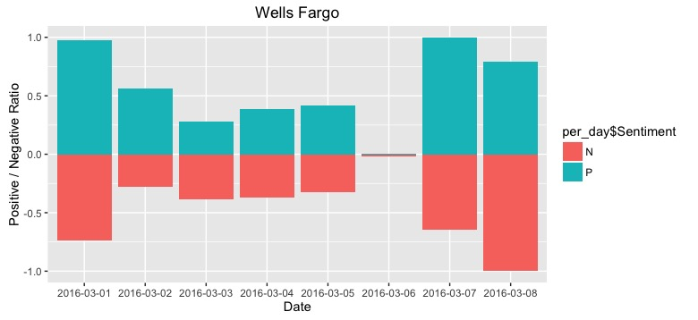

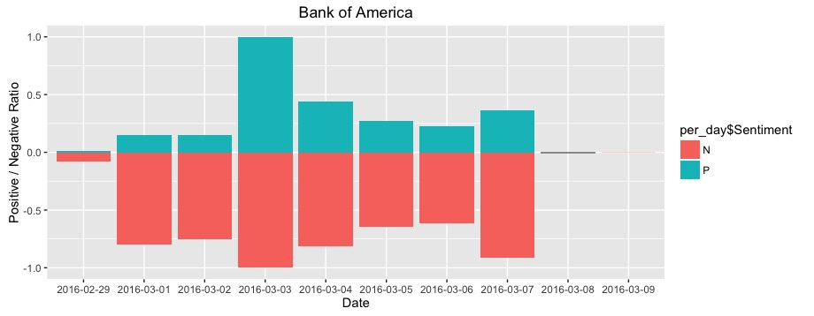

These are visually stunning but aren’t terribly informative, as it’s hard to tell if there are more positive or negative tweets. A ratio of positive to negative tweets should be more interesting.

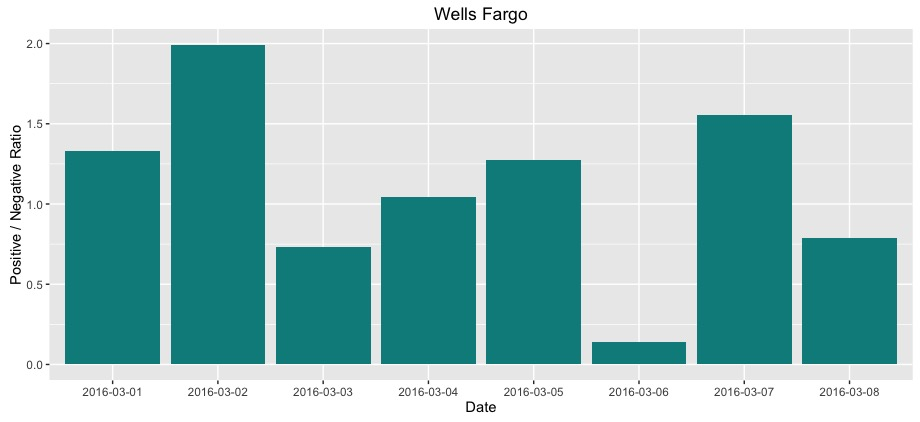

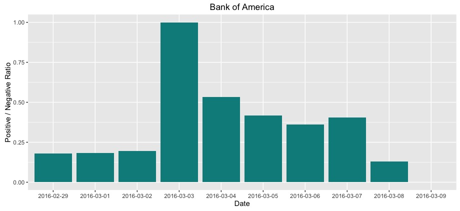

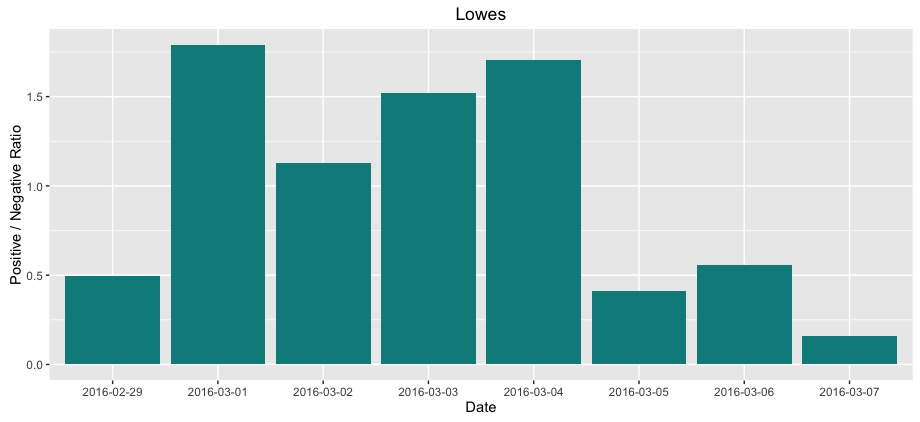

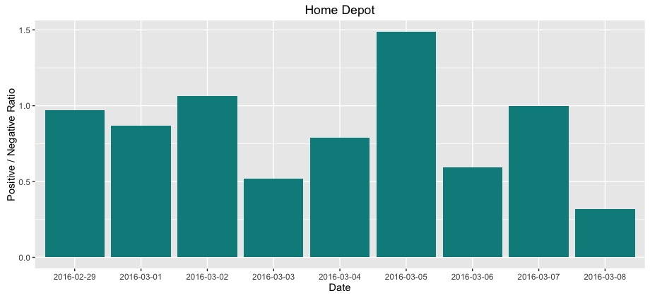

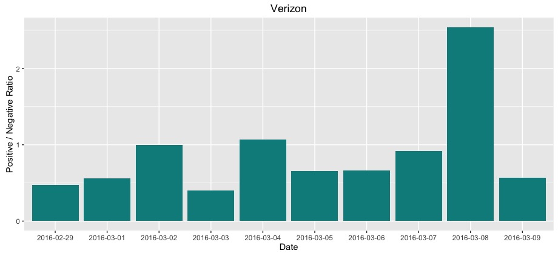